# Project1

Minzhe Zhang

2018/2/11

```r
### read data
senic.data <- read.csv("senic.csv")
senic.data$region.factor <- as.factor(senic.data$region)
```

### Question 1

#### a)

H0: mean infection risk is the same in the four geographic regions.  
Ha: mean infection risk is not all equal in the four geographic regions.  
Conclusion: mean infection risk is not all equal in the four geographic regions.

```r
anova.model <- aov(infprob ~ region.factor, data = senic.data)
summary(anova.model)
```

```
##                Df Sum Sq Mean Sq F value Pr(>F)
## region.factor   3   14.0   4.666   2.714 0.0484 *
## Residuals     109  187.4   1.719
## ---
## Signif. codes:  0 '***' 0.001 '**' 0.01 '*' 0.05 '.' 0.1 ' ' 1
```

#### b)

Conclusion: Based on Tukey procedure, group mean between region 1 and 3 is significant, others are all non significant.

```r
T.term <- 1/sqrt(2)*qtukey(0.9, nmeans = 4, df = 113 - 4)
mse <- summary(anova.model)[[1]]$`Mean Sq`[2]
inf.count <- aggregate(list(count = senic.data$infprob), by = list(region = senic.data$region), FUN = length)
inf.mean <- aggregate(list(inf.mean = senic.data$infprob), by = list(region = senic.data$region), FUN = mean)
inf.group <- merge(inf.count, inf.mean, by = "region")
diff.inter <- data.frame(t(combn(1:4, 2)), mean = rep(NA, 6), var = rep(NA, 6), left.tukey = rep(NA, 6), right.tukey = rep(NA, 6))
for (i in 1:4) for (j in i:4) {
      k <- diff.inter$X1 == i & diff.inter$X2 == j
      diff.inter$mean[k] <- abs(inf.group$inf.mean[i] - inf.group$inf.mean[j])
      diff.inter$var[k] <- sqrt(mse * (1/inf.group$count[i] + 1/inf.group$count[j]))
      diff.inter$left.tukey[k] <- diff.inter$mean[k] - T.term * diff.inter$var[k]
      diff.inter$right.tukey[k] <- diff.inter$mean[k] + T.term * diff.inter$var[k]
}
diff.inter
```

```
##   X1 X2      mean       var left.tukey right.tukey
## 1  1  2 0.4669643 0.3392918 -0.3198415   1.2537701
## 2  1  3 0.9336873 0.3284192  0.1720946   1.6952799
## 3  1  4 0.4794643 0.4109027 -0.4734048   1.4323334
## 4  2  3 0.4667230 0.3165195 -0.2672746   1.2007205
## 5  2  4 0.0125000 0.4014554 -0.9184612   0.9434612
## 6  3  4 0.4542230 0.3923095 -0.4555290   1.3639749
```

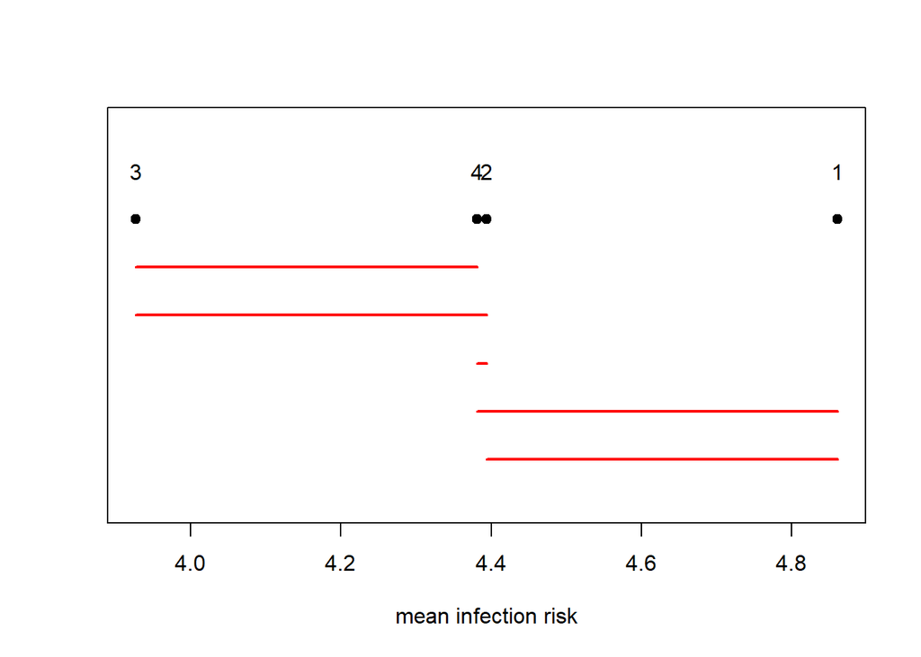

```r
nonsig.line <- function(comp.list) {
      height <- 0.95
      for(item in comp.list) {
            x0 <- inf.group$inf.mean[item[1]]; x1 <- inf.group$inf.mean[item[2]]
            y0 <- y1 <- height; height <- height - 0.05
            segments(x0, y0, x1, y1, col = "red", lwd = 2)
      }
}
plot(inf.group$inf.mean, c(1,1,1,1), pch = 19, ylim = c(0.7, 1.1), yaxt = "n", xlab = "mean infection risk", ylab = "")
text(inf.group$inf.mean, rep(1.05, 4), c("1", "2", "3", "4"))
nonsig.line(list(c(3,4), c(3,2), c(4,2), c(4,1), c(2,1)))
```

#### c)

Using Scheffe procedure, conclusion is same as Tukey, group mean between region 1 and 3 is significant, others are all non significant.

```r
S.term <- sqrt((4 - 1) * qf(0.9, df1 = 4 - 1, df2 = 113 - 4))
diff.inter <- data.frame(diff.inter, left.scheffe = rep(NA, 6), right.scheffe = rep(NA, 6))
for (i in 1:4) for (j in i:4) {
      k <- diff.inter$X1 == i & diff.inter$X2 == j
      diff.inter$left.scheffe[k] <- diff.inter$mean[k] - S.term * diff.inter$var[k]
      diff.inter$right.scheffe[k] <- diff.inter$mean[k] + S.term * diff.inter$var[k]
}
diff.inter[,-c(5,6)]
```

```
##   X1 X2      mean       var left.scheffe right.scheffe
## 1  1  2 0.4669643 0.3392918   -0.3916626      1.325591
## 2  1  3 0.9336873 0.3284192    0.1025750      1.764799
## 3  1  4 0.4794643 0.4109027   -0.5603845      1.519313
## 4  2  3 0.4667230 0.3165195   -0.3342753      1.267721
## 5  2  4 0.0125000 0.4014554   -1.0034411      1.028441
## 6  3  4 0.4542230 0.3923095   -0.5385729      1.447019
```

### Question 2

H0: There is no significant difference of mean infection risk between different age groups.  
Ha: Not all age groups have same mean infection risk.  
p value is 0.805, greater than the significance level 0.1.  
Conclusion: Meaninfection risk does not differs for the four age groups.

```r
senic.data$age.group <- cut(senic.data$age, breaks = c(0, 50, 55, 60, Inf))
anova.model.2 <- aov(infprob ~ age.group, data = senic.data)
F.value <- summary(anova.model.2)[[1]]$`F value`[1]
p.value <- pf(F.value, df1 = 4 - 1, df2 = 113 - 4, lower.tail = FALSE)
summary(anova.model.2)
```

```
##              Df Sum Sq Mean Sq F value Pr(>F)
## age.group     3    1.8  0.6016   0.329  0.805
## Residuals   109  199.6  1.8310
```

### Question 3

#### a)

There may be two outliers in region 1.

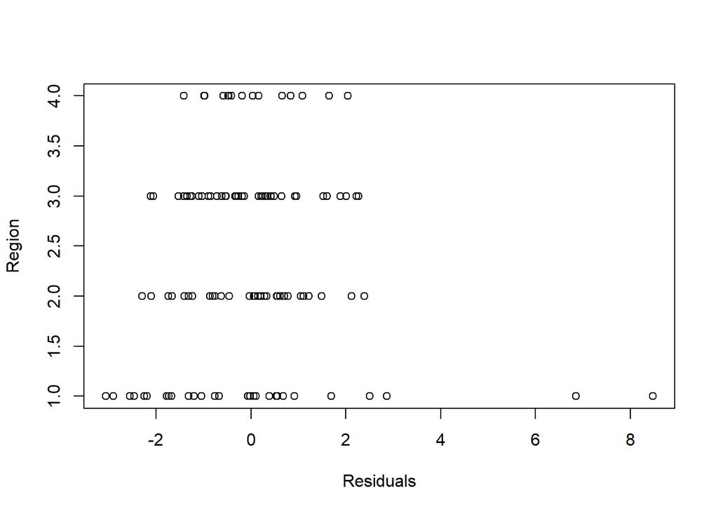

```r
anova.model.3 <- aov(stay ~ region.factor, data = senic.data)
plot(anova.model.3$residuals, senic.data$region, xlab = "Residuals", ylab = "Region")
```

#### b)

p.value is smaller than significance level 0.05, variance is not contant among different groups.

```r
suppressWarnings(library(onewaytests))
bf.test(stay ~ region.factor, data = senic.data)
```

```
##
##   Brown-Forsythe Test
## ---------------------------------------------------------
##   data : stay and region.factor
##
##   statistic  : 12.5459
##   num df     : 3
##   denom df   : 57.93179
##   p.value    : 1.995795e-06
##
##   Result     : Difference is statistically significant.
## ---------------------------------------------------------
```

#### c)

Sigma divided by mean square gives the most stable result. So reciprocal transformation is probably the most appropriate one.

```r
stay.mean <- aggregate(list(stay.mean = senic.data$stay), by = list(region =  senic.data$region), FUN = mean)
stay.var <- aggregate(list(stay.var = senic.data$stay), by = list(region =  senic.data$region), FUN = var)
stay.group <- merge(stay.mean, stay.var, by = "region")
stay.group$var.d.mean <- apply(stay.group[,c(2,3)], 1, FUN = function(x) x[2]/x[1])
stay.group$sigma.d.mean <- apply(stay.group[,c(2,3)], 1, FUN = function(x) sqrt(x[2])/x[1])
stay.group$var.d.mean2 <- apply(stay.group[,c(2,3)], 1, FUN = function(x) sqrt(x[2])/x[1]^2)
stay.group
```

```
##   region stay.mean stay.var var.d.mean sigma.d.mean var.d.mean2
## 1      1 11.088929 7.126847  0.6426993    0.2407460  0.02171049
## 2      2  9.683438 1.423101  0.1469623    0.1231936  0.01272210
## 3      3  9.191351 1.500595  0.1632617    0.1332761  0.01450017
## 4      4  8.113750 1.006252  0.1240181    0.1236322  0.01523737
```

#### d)

Based on Box-Cox procedure, lambda = -1, a reciprocal transformation is reasonable.

```r
lambdas <- seq(-1, 1, 0.1)
box.procedure <- function(values, groups, lambdas) {
      SSE <- rep(NA, length(lambdas))
      for (i in 1:length(lambdas)) {
            lambda <- lambdas[i]
            K2 <- prod(values)^(1/length(values))
            K1 <- 1 / (lambda * K2^(lambda-1))
            if (lambda != 0) W <- K1 * (values^lambda - 1)
            else W <- K2 * log(values)
            ### anova
            tmp.anova <- aov(W ~ groups)
            SSE[i] <- summary(tmp.anova)[[1]]$`Sum Sq`[2]
      }
      return(data.frame(lambdas = lambdas, SSE = SSE))
}
box.table <- box.procedure(values = senic.data$stay, groups = senic.data$region.factor, lambdas = lambdas)
box.table
```

```
##    lambdas      SSE
## 1     -1.0 206.1479
## 2     -0.9 207.2180
## 3     -0.8 208.5545
## 4     -0.7 210.1716
## 5     -0.6 212.0852
## 6     -0.5 214.3128
## 7     -0.4 216.8741
## 8     -0.3 219.7909
## 9     -0.2 223.0873
## 10    -0.1 226.7903
## 11     0.0 230.9296
## 12     0.1 235.5380
## 13     0.2 240.6522
## 14     0.3 246.3126
## 15     0.4 252.5638
## 16     0.5 259.4553
## 17     0.6 267.0421
## 18     0.7 275.3847
## 19     0.8 284.5503
## 20     0.9 294.6133
## 21     1.0 305.6562
```

#### e)

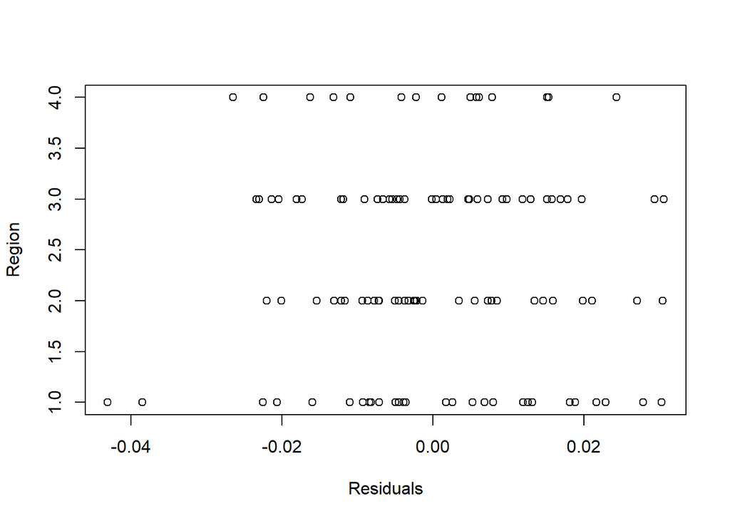

```r
senic.data$stay.recip <- 1/senic.data$stay
anova.model.3.1 <- aov(stay.recip ~ region.factor, data = senic.data)
plot(anova.model.3.1$residuals, senic.data$region, xlab = "Residuals", ylab = "Region")
```

#### f)

The variance is still not equal on transfomed response.

```r
bf.test(stay.recip ~ region.factor, data = senic.data)
```

```
##
##   Brown-Forsythe Test
## ---------------------------------------------------------
##   data : stay.recip and region.factor
##
##   statistic  : 14.63928
##   num df     : 3
##   denom df   : 87.62875
##   p.value    : 8.275604e-08
##
##   Result     : Difference is statistically significant.
## ---------------------------------------------------------
```